# LI-6800 和 LI-6400 光合数据分析指南 - 18 C4 植物光合模拟

之前的部分模型全部为关于 C3 植物的拟合，而 Caemmerer (2000) 的方法，则是针对 C4 植物的 A-Ci 曲线的实现。

```r
AciC4(Ci, PPFD = 1500, Tleaf = 25, VPMAX25 = 120,
      JMAX25 = 400, Vcmax = 60, Vpr = 80,
      alpha = 0, gbs = 0.003, O2 = 210,
      x = 0.4, THETA = 0.7, Q10 = 2.3,
      RD0 = 1, RTEMP = 25, TBELOW = 0,
      DAYRESP = 1, Q10F = 2, FRM = 0.5, ...)
```

以上参数均来自 Caemmerer (2000)，括号中的参数值均为默认值，具体应用时请按照实际情况修改。

## 18.1 C4 植物光合速率的计算

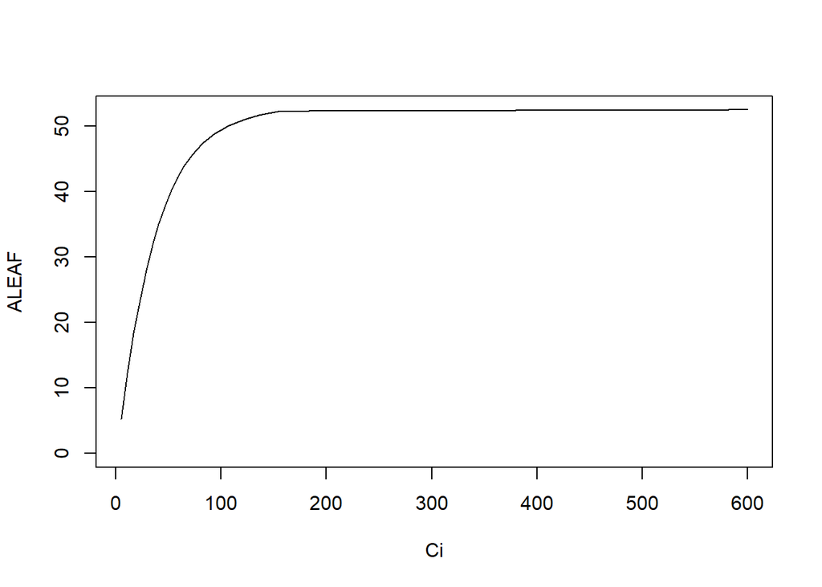

Figure 18.1: AciC4 模拟一定 Ci 梯度下光合速率的变化

```r
# 模拟 C4 植物的 Ci 值，计算光合速率并作图
library(plantecophys)
aci <- AciC4(Ci=seq(5,600, length=101))
with(aci, plot(Ci, ALEAF, type='l', ylim=c(0,max(ALEAF))))
```

**注意**

目前无法利用该函数来拟合观测到数据。

Caemmerer, S. Von. 2000. “Biochemical Models of Leaf Photosynthesis.” *Quarterly Review of Biology*, 165.